# SIRTA - Données capteurs LCSQA

Auteur·rice

Amandine Fievet, Laurent Spinelle

DERNIÈRE MISE À JOUR DE LA BASE DE DONNéES

08 juin 2026

## Colocalisation de système capteurs à l’observatoire de recherche atmosphérique SIRTA

Suite aux travaux menés en 2021[^1], Ineris, membre du Laboratoire Central de Surveillance de la Qualité de l’Air (LCSQA), en collaboration avec le Laboratoire des Sciences du Climat et de l’Environnement (LSCE), ont pris l’initiative de créer un jeu de données incluant à la fois des données de mesure de la qualité de l’air issues d’appareils de mesure de référence ou équivalents à des références, ainsi que des systèmes capteurs présentant différents niveaux d’algorithmes de correction. Ce document regroupe l’ensemble des informations concernant ce jeu de données.

L’ensemble du jeu de données couvre la période allant du 2025-01-01 au 2026-06-08. Une mise à jour périodique du jeu de données sera effectuée.

## Liste des appareils de mesure de référence

Voici la liste des appareils utilisés pour mesurer les gaz et les particules :

- un analyseur de CO modèle **API 300E** de **Teledyne**.
- un analyseur de NO<sub>x</sub> modèle **APNA-370** de **Horiba**.
- un analyseur de O<sub>3</sub> **modèle 49i** de **Thermo Scientific**.
- un **FIDAS 200** de **Palas** pour la mesure optique des PMs.
- deux **TEOM FDMS 1405-F** de **Thermo Scientific** pour la mesure gravimétriques des PM1 et PM10.

## Accès aux données

**Téléchargement du jeu de données complet**

Le fichier contient l’ensemble des mesures (météo, gaz, PM et capteurs) au format CSV.

[**Télécharger le fichier CSV**](https://doi.org/10.5281/zenodo.19484839)

## Gantt chart des conditions expérimentales

La Figure 1 illustre la disponibilité des données des variables des conditions expérimentales au cours de l’intégralité de la période expérimentale.

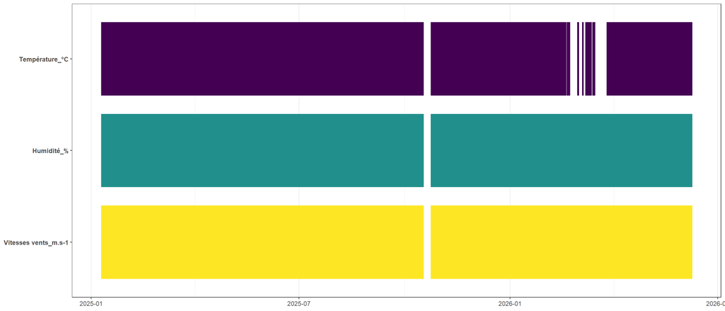

Figure 1: Disponibilité temporelle des mesures pour les variables météorologiques.

## Séries temporelles et tableau statistique des conditions expérimentales

La Figure 2 représente les séries temporelles des conditions environnementales observées durant cette expérimentation.

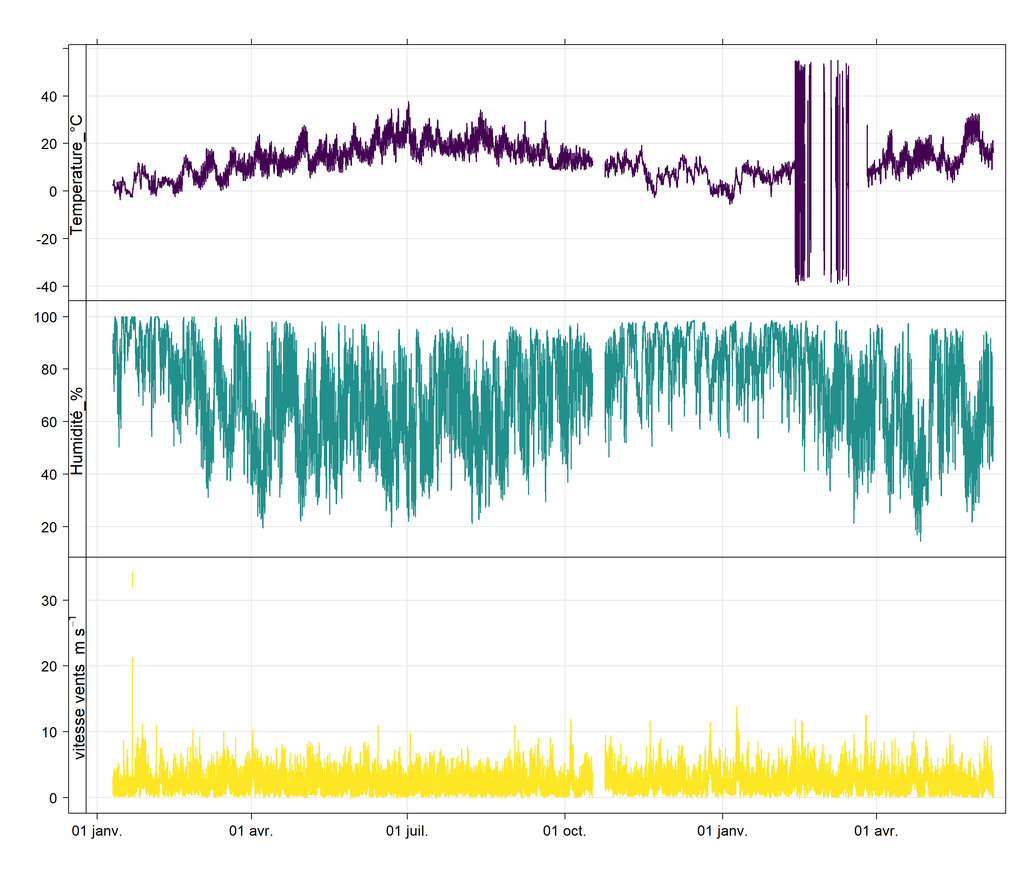

Figure 2: Séries temporelles des conditions environnementales relevées durant l’ensemble de la période de colocalisation.

Le Table 1 regroupe les valeurs minimales, maximales, moyennes et médianes de température, d’humidité relative et de vitesse du vent observées pendant l’intégralité de la période expérimentale.

Table 1: Tableau statistique des conditions environnementales relevées lors de l’intégralité de la période expérimentale.

| Paramètre | Minimum | Maximum | Moyenne | Mediane | Ecart_Type | N_valide |
| --- | --- | --- | --- | --- | --- | --- |
| Humidité_% | 14.4675 | 100 | 72.02134070328549 | 75.60583333333334 | 18.6058652386327 | 729601 |
| Température_°C | -39.57333333333333 | 54.97583333333333 | 12.33741027923547 | 11.94583333333333 | 7.276556802128309 | 675720 |
| Vitesse vents_m/s | 0.03083333333333333 | 34.13500000000001 | 2.3855713901603 | 2.17 | 1.34201374948368 | 729425 |

## Rose des vents

La Figure 3 regroupe les roses des vents réalisées mensuellement pour l’année 2025.

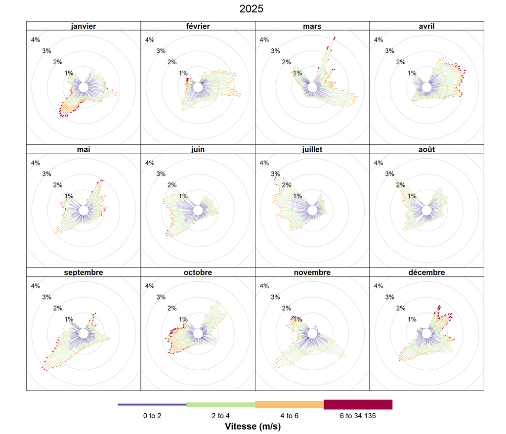

Figure 3: Matrice mensuelle des roses des vents 2025

La Figure 4 regroupe les roses des vents réalisées mensuellement pour l’année 2026.

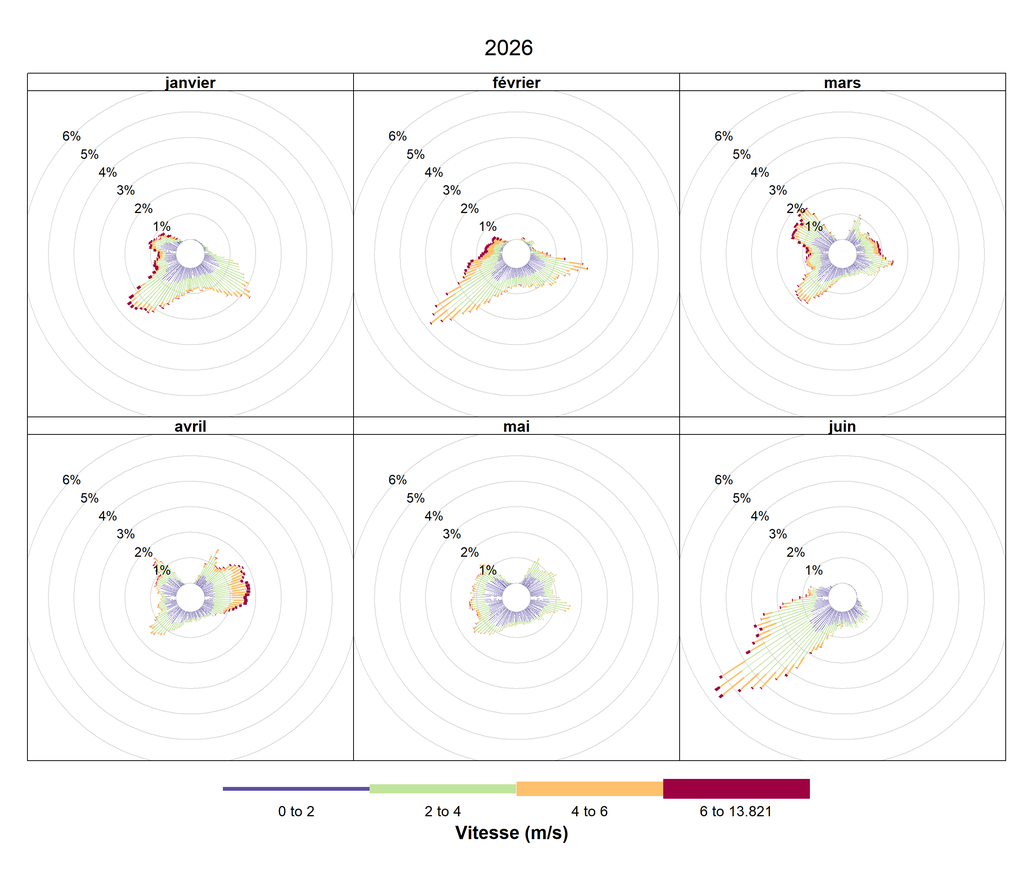

Figure 4: Matrice mensuelle des roses des vents 2026

## Gantt chart des polluants atmosphériques gazeux

La Figure 5 illustre la disponibilité des données des variables de polluants atmosphériques gazeux au cours de l’intégralité de la période expérimentale.

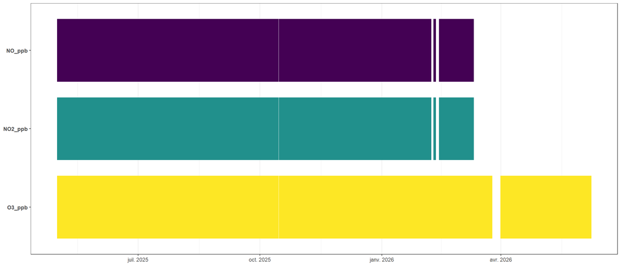

Figure 5: Disponibilité temporelle des mesures pour les variables de polluants atmosphériques.

## Séries temporelles et tableau statistique des concentrations en polluants atmosphériques gazeux

La Figure 6 représente les séries temporelles des concentrations en polluants atmosphériques gazeux observées durant cette expérimentation.

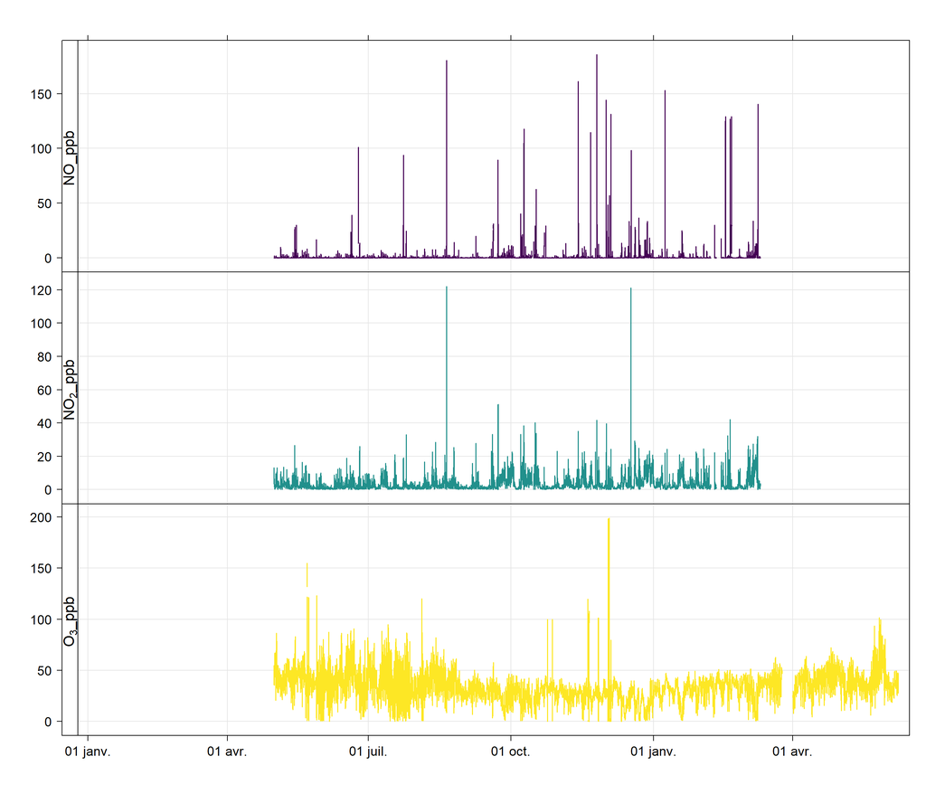

Figure 6: Séries temporelles des concentrations en polluants gazeux relevées durant l’ensemble de la période de colocalisation.

Le Table 2 regroupe les valeurs minimales, maximales, moyennes et médianes des concentrations en gaz observées pendant l’intégralité de la période expérimentale.

Table 2: Tableau statistique des concentrations relevées lors de l’intégralité de la période expérimentale.

| Polluant | Min | Max | Moyenne | Mediane | Ecart_Type | N_valide |
| --- | --- | --- | --- | --- | --- | --- |
| NO2_ppb | 0 | 122.1402 | 3.413906116149407 | 1.9613 | 4.068814460469238 | 441397 |
| NO_ppb | 0 | 185.6973 | 0.9631550891570444 | 0.1195 | 4.411895929900614 | 334466 |
| O3_ppb | 0.0033589599188417 | 199.095611572266 | 33.76413988999112 | 32.7934722900391 | 13.28750119982763 | 569032 |

## Gantt chart des polluants atmosphériques particulaires

La Figure 7 illustre la disponibilité des données des variables de polluants atmosphériques particulaires au cours de l’intégralité de la période expérimentale.

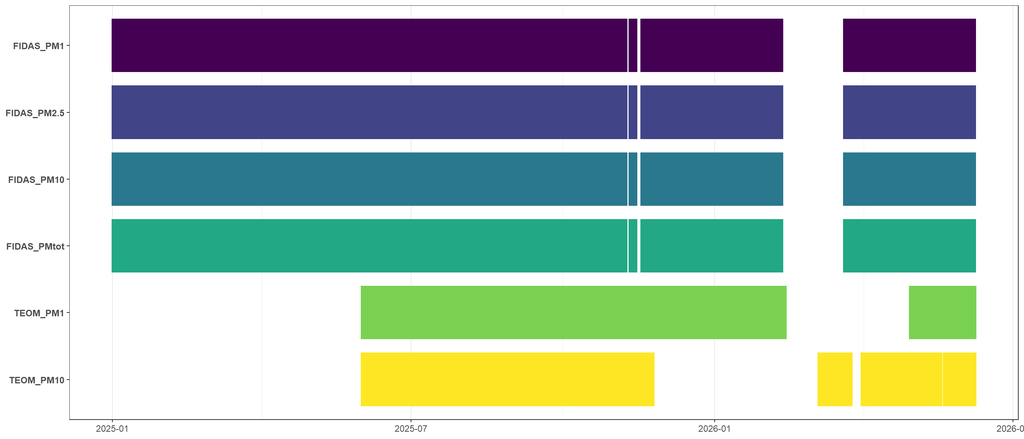

Figure 7: Disponibilité temporelle des mesures pour les variables de polluants particulaires.

## Séries temporelles et tableau statistique des concentrations en polluants atmosphériques particulaires

La Figure 8 représente les séries temporelles des concentrations en polluants atmosphériques particulaires observées durant cette expérimentation.

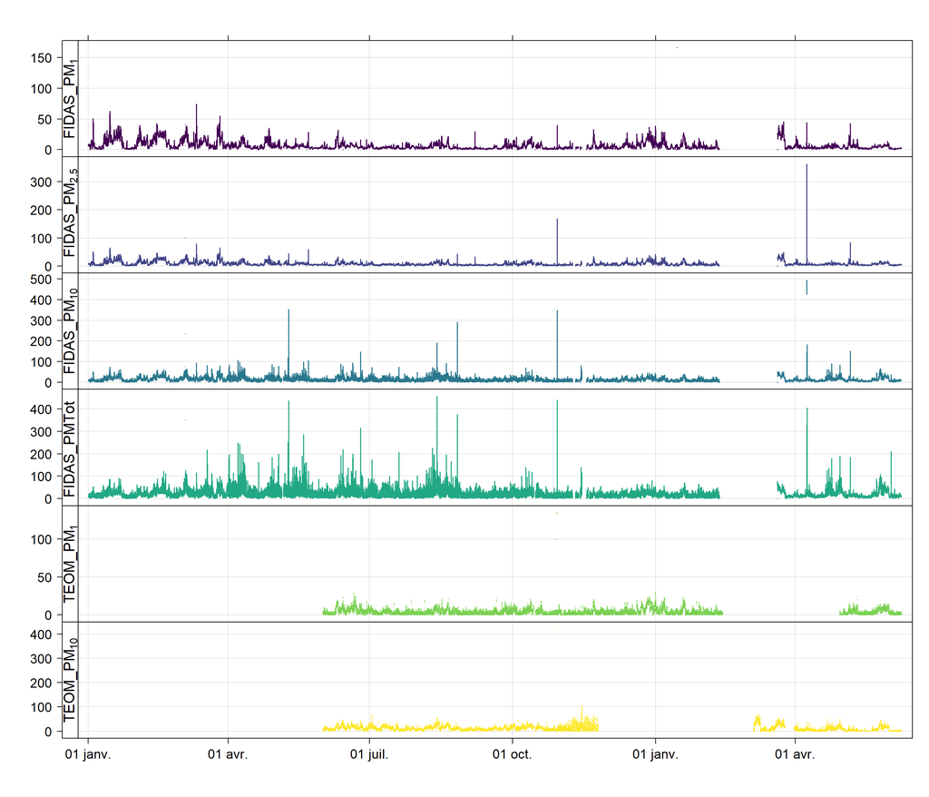

Figure 8: Séries temporelles des concentrations en polluants particulaires relevées durant l’ensemble de la période de colocalisation.

Le Table 3 regroupe les valeurs minimales, maximales, moyennes et médianes des concentrations en particules observées pendant l’intégralité de la période expérimentale.

Table 3: Tableau statistique des concentrations relevées lors de l’intégralité de la période expérimentale.

| Polluant | Min | Max | Moyenne | Mediane | Ecart_Type | N_valide |
| --- | --- | --- | --- | --- | --- | --- |
| FIDAS_PM10_µg/m3 | 0 | 493.421633 | 12.316516986023 | 9.930275 | 8.835158935247724 | 684911 |
| FIDAS_PM1_µg/m3 | 0 | 166.347022 | 6.475583871584225 | 4.159658 | 6.449898297705427 | 684947 |
| FIDAS_PM2.5_µg/m3 | 0 | 363.644893 | 7.999024442258138 | 5.776105 | 6.87414775565817 | 684945 |
| FIDAS_PMtot_µg/m3 | 0 | 455.511384 | 16.82198123381993 | 12.862001 | 14.03573246616323 | 684901 |
| TEOM_PM10_µg/m3 | 0 | 421.3 | 13.28353653207481 | 10.9 | 10.4418760592353 | 22884 |
| TEOM_PM1_µg/m3 | 0 | 134.759 | 4.736504254340027 | 3.81134 | 4.089819031485963 | 24251 |

## Note

Ces valeurs sont fournies brutes et peuvent être soumises a posteriori correction.

Pour une meilleure lisibilité dans ce rapport, les données utilisées pour l’édition des graphiques et des tableaux ont été encadrées de la façon suivante:

- 0 µg/m3 < composés particulaires < 500 µg/m3
- 0 ppb < composés gazeux < 200 ppb
- -40 °C < température < 55 °C

Pour toute question, veuillez contacter Laurent Spinelle par e-mail *laurent.spinelle@ineris.fr* ou par téléphone *+33 (0)3 44 55 69 86* (ligne fixe) ou *+33 (0)7 86 42 59 15* (téléphone portable).

## Notes de bas de page

[^1]: Contexte de la création d’un jeu de données de tests des algorithmes incluant des données capteurs et des données d’appareils de référence, https://www.lcsqa.org/fr/rapport/contexte-de-la-creation-dun-jeu-de-donnees-de-tests-des-algorithmes-incluant-des-donnees